# Risk Factor Analysis

## Outcome Variable

**Outcome Variable:** wasted

## Predictor Variables

**Intervention Variable:** enstunt

**Adjustment Set:**

- arm
- sex
- W_mage
- meducyrs
- feducyrs
- vagbrth
- single
- brthmon
- W_parity
- delta_W_mage
- delta_meducyrs
- delta_feducyrs
- delta_vagbrth
- delta_single
- delta_brthmon
- delta_W_parity

## Stratifying Variables

The analysis was stratified on these variable(s):

- agecat
- studyid
- country

## Data Summary

| agecat | studyid | country | enstunt | wasted | n_cell | n |
| --- | --- | --- | --- | --- | --- | --- |
| Birth | CMC-V-BCS-2002 | INDIA | 0 | 0 | 66 | 86 |
| Birth | CMC-V-BCS-2002 | INDIA | 0 | 1 | 8 | 86 |
| Birth | CMC-V-BCS-2002 | INDIA | 1 | 0 | 9 | 86 |
| Birth | CMC-V-BCS-2002 | INDIA | 1 | 1 | 3 | 86 |
| Birth | CMIN | BANGLADESH | 0 | 0 | 14 | 19 |
| Birth | CMIN | BANGLADESH | 0 | 1 | 3 | 19 |
| Birth | CMIN | BANGLADESH | 1 | 0 | 1 | 19 |
| Birth | CMIN | BANGLADESH | 1 | 1 | 1 | 19 |
| Birth | COHORTS | GUATEMALA | 0 | 0 | 540 | 756 |
| Birth | COHORTS | GUATEMALA | 0 | 1 | 192 | 756 |
| Birth | COHORTS | GUATEMALA | 1 | 0 | 24 | 756 |
| Birth | COHORTS | GUATEMALA | 1 | 1 | 0 | 756 |
| Birth | COHORTS | INDIA | 0 | 0 | 4772 | 6193 |
| Birth | COHORTS | INDIA | 0 | 1 | 1041 | 6193 |
| Birth | COHORTS | INDIA | 1 | 0 | 325 | 6193 |
| Birth | COHORTS | INDIA | 1 | 1 | 55 | 6193 |
| Birth | COHORTS | PHILIPPINES | 0 | 0 | 2373 | 2899 |
| Birth | COHORTS | PHILIPPINES | 0 | 1 | 440 | 2899 |
| Birth | COHORTS | PHILIPPINES | 1 | 0 | 75 | 2899 |
| Birth | COHORTS | PHILIPPINES | 1 | 1 | 11 | 2899 |
| Birth | CONTENT | PERU | 0 | 0 | 2 | 2 |
| Birth | CONTENT | PERU | 0 | 1 | 0 | 2 |
| Birth | CONTENT | PERU | 1 | 0 | 0 | 2 |
| Birth | CONTENT | PERU | 1 | 1 | 0 | 2 |
| Birth | EE | PAKISTAN | 0 | 0 | 120 | 177 |
| Birth | EE | PAKISTAN | 0 | 1 | 17 | 177 |
| Birth | EE | PAKISTAN | 1 | 0 | 35 | 177 |
| Birth | EE | PAKISTAN | 1 | 1 | 5 | 177 |
| Birth | GMS-Nepal | NEPAL | 0 | 0 | 450 | 641 |
| Birth | GMS-Nepal | NEPAL | 0 | 1 | 120 | 641 |

[output cut: 298 more lines]

The following strata were considered:

- agecat: 24 months, studyid: CMC-V-BCS-2002, country: INDIA
- agecat: 24 months, studyid: CMIN, country: BANGLADESH
- agecat: 24 months, studyid: COHORTS, country: GUATEMALA
- agecat: 24 months, studyid: COHORTS, country: INDIA
- agecat: 24 months, studyid: COHORTS, country: PHILIPPINES
- agecat: 24 months, studyid: CONTENT, country: PERU
- agecat: 24 months, studyid: EE, country: PAKISTAN
- agecat: 24 months, studyid: GMS-Nepal, country: NEPAL
- agecat: 24 months, studyid: IRC, country: INDIA
- agecat: 24 months, studyid: JiVitA-3, country: BANGLADESH
- agecat: 24 months, studyid: JiVitA-4, country: BANGLADESH
- agecat: 24 months, studyid: Keneba, country: GAMBIA
- agecat: 24 months, studyid: LCNI-5, country: MALAWI
- agecat: 24 months, studyid: MAL-ED, country: BANGLADESH
- agecat: 24 months, studyid: MAL-ED, country: BRAZIL
- agecat: 24 months, studyid: MAL-ED, country: INDIA
- agecat: 24 months, studyid: MAL-ED, country: NEPAL
- agecat: 24 months, studyid: MAL-ED, country: PERU
- agecat: 24 months, studyid: MAL-ED, country: SOUTH AFRICA
- agecat: 24 months, studyid: MAL-ED, country: TANZANIA, UNITED REPUBLIC OF
- agecat: 24 months, studyid: NIH-Birth, country: BANGLADESH
- agecat: 24 months, studyid: NIH-Crypto, country: BANGLADESH
- agecat: 24 months, studyid: PROBIT, country: BELARUS
- agecat: 24 months, studyid: PROVIDE, country: BANGLADESH
- agecat: 24 months, studyid: TanzaniaChild2, country: TANZANIA, UNITED REPUBLIC OF
- agecat: 24 months, studyid: ZVITAMBO, country: ZIMBABWE
- agecat: 6 months, studyid: CMC-V-BCS-2002, country: INDIA
- agecat: 6 months, studyid: CMIN, country: BANGLADESH
- agecat: 6 months, studyid: COHORTS, country: GUATEMALA
- agecat: 6 months, studyid: COHORTS, country: INDIA
- agecat: 6 months, studyid: COHORTS, country: PHILIPPINES
- agecat: 6 months, studyid: CONTENT, country: PERU
- agecat: 6 months, studyid: EE, country: PAKISTAN
- agecat: 6 months, studyid: GMS-Nepal, country: NEPAL
- agecat: 6 months, studyid: Guatemala BSC, country: GUATEMALA
- agecat: 6 months, studyid: IRC, country: INDIA
- agecat: 6 months, studyid: JiVitA-3, country: BANGLADESH
- agecat: 6 months, studyid: JiVitA-4, country: BANGLADESH
- agecat: 6 months, studyid: Keneba, country: GAMBIA
- agecat: 6 months, studyid: LCNI-5, country: MALAWI
- agecat: 6 months, studyid: MAL-ED, country: BANGLADESH
- agecat: 6 months, studyid: MAL-ED, country: BRAZIL
- agecat: 6 months, studyid: MAL-ED, country: INDIA
- agecat: 6 months, studyid: MAL-ED, country: NEPAL
- agecat: 6 months, studyid: MAL-ED, country: PERU
- agecat: 6 months, studyid: MAL-ED, country: SOUTH AFRICA
- agecat: 6 months, studyid: MAL-ED, country: TANZANIA, UNITED REPUBLIC OF
- agecat: 6 months, studyid: NIH-Birth, country: BANGLADESH
- agecat: 6 months, studyid: NIH-Crypto, country: BANGLADESH
- agecat: 6 months, studyid: PROBIT, country: BELARUS
- agecat: 6 months, studyid: PROVIDE, country: BANGLADESH
- agecat: 6 months, studyid: ResPak, country: PAKISTAN
- agecat: 6 months, studyid: SAS-CompFeed, country: INDIA
- agecat: 6 months, studyid: SAS-FoodSuppl, country: INDIA
- agecat: 6 months, studyid: TanzaniaChild2, country: TANZANIA, UNITED REPUBLIC OF
- agecat: 6 months, studyid: ZVITAMBO, country: ZIMBABWE
- agecat: Birth, studyid: CMC-V-BCS-2002, country: INDIA
- agecat: Birth, studyid: CMIN, country: BANGLADESH
- agecat: Birth, studyid: COHORTS, country: GUATEMALA
- agecat: Birth, studyid: COHORTS, country: INDIA
- agecat: Birth, studyid: COHORTS, country: PHILIPPINES
- agecat: Birth, studyid: CONTENT, country: PERU
- agecat: Birth, studyid: EE, country: PAKISTAN
- agecat: Birth, studyid: GMS-Nepal, country: NEPAL
- agecat: Birth, studyid: IRC, country: INDIA
- agecat: Birth, studyid: JiVitA-3, country: BANGLADESH
- agecat: Birth, studyid: JiVitA-4, country: BANGLADESH
- agecat: Birth, studyid: Keneba, country: GAMBIA
- agecat: Birth, studyid: MAL-ED, country: BANGLADESH
- agecat: Birth, studyid: MAL-ED, country: BRAZIL
- agecat: Birth, studyid: MAL-ED, country: INDIA
- agecat: Birth, studyid: MAL-ED, country: NEPAL
- agecat: Birth, studyid: MAL-ED, country: PERU
- agecat: Birth, studyid: MAL-ED, country: SOUTH AFRICA
- agecat: Birth, studyid: MAL-ED, country: TANZANIA, UNITED REPUBLIC OF
- agecat: Birth, studyid: NIH-Birth, country: BANGLADESH
- agecat: Birth, studyid: NIH-Crypto, country: BANGLADESH
- agecat: Birth, studyid: PROBIT, country: BELARUS
- agecat: Birth, studyid: PROVIDE, country: BANGLADESH
- agecat: Birth, studyid: ResPak, country: PAKISTAN
- agecat: Birth, studyid: SAS-CompFeed, country: INDIA
- agecat: Birth, studyid: ZVITAMBO, country: ZIMBABWE

### Dropped Strata

Some strata were dropped due to rare outcomes:

- agecat: Birth, studyid: CMC-V-BCS-2002, country: INDIA
- agecat: Birth, studyid: CMIN, country: BANGLADESH
- agecat: Birth, studyid: COHORTS, country: GUATEMALA
- agecat: Birth, studyid: CONTENT, country: PERU
- agecat: Birth, studyid: IRC, country: INDIA
- agecat: Birth, studyid: Keneba, country: GAMBIA
- agecat: Birth, studyid: MAL-ED, country: BANGLADESH
- agecat: Birth, studyid: MAL-ED, country: BRAZIL
- agecat: Birth, studyid: MAL-ED, country: INDIA
- agecat: Birth, studyid: MAL-ED, country: NEPAL
- agecat: Birth, studyid: MAL-ED, country: PERU
- agecat: Birth, studyid: MAL-ED, country: SOUTH AFRICA
- agecat: Birth, studyid: MAL-ED, country: TANZANIA, UNITED REPUBLIC OF
- agecat: Birth, studyid: PROBIT, country: BELARUS
- agecat: Birth, studyid: ResPak, country: PAKISTAN
- agecat: 6 months, studyid: CONTENT, country: PERU
- agecat: 6 months, studyid: Guatemala BSC, country: GUATEMALA
- agecat: 6 months, studyid: MAL-ED, country: BANGLADESH
- agecat: 6 months, studyid: MAL-ED, country: BRAZIL
- agecat: 6 months, studyid: MAL-ED, country: INDIA
- agecat: 6 months, studyid: MAL-ED, country: NEPAL
- agecat: 6 months, studyid: MAL-ED, country: PERU
- agecat: 6 months, studyid: MAL-ED, country: SOUTH AFRICA
- agecat: 6 months, studyid: MAL-ED, country: TANZANIA, UNITED REPUBLIC OF
- agecat: 6 months, studyid: PROBIT, country: BELARUS
- agecat: 6 months, studyid: TanzaniaChild2, country: TANZANIA, UNITED REPUBLIC OF
- agecat: 24 months, studyid: CONTENT, country: PERU
- agecat: 24 months, studyid: LCNI-5, country: MALAWI
- agecat: 24 months, studyid: MAL-ED, country: BANGLADESH
- agecat: 24 months, studyid: MAL-ED, country: BRAZIL
- agecat: 24 months, studyid: MAL-ED, country: NEPAL
- agecat: 24 months, studyid: MAL-ED, country: PERU
- agecat: 24 months, studyid: MAL-ED, country: SOUTH AFRICA
- agecat: 24 months, studyid: MAL-ED, country: TANZANIA, UNITED REPUBLIC OF
- agecat: 24 months, studyid: PROBIT, country: BELARUS
- agecat: 24 months, studyid: TanzaniaChild2, country: TANZANIA, UNITED REPUBLIC OF

## Methods Detail

We’re interested in the causal parameters $E[Y_a]$ for all values of $a \in \mathcal{A}$. These parameters represent the mean outcome if, possibly contrary to fact, we intervened to set all units to have $A=a$. Under the randomization and positivity assumptions, these are identified by the statistical parameters $\psi_a=E_W[E_{Y|A,W}(Y|A=a,W)]$. In addition, we’re interested in the mean of $Y$, $E[Y]$ under no intervention (the observed mean). We will estimate these parameters by using SuperLearner to fit the relevant likelihood factors – $E_{Y|A,W}(Y|A=a,W)$ and $p(A=a|W)$, and then updating our likelihood fit using a joint TMLE.

For unadjusted analyses ($W=\{\}$), initial likelihoods were estimated using Lrnr_glm to estimate the simple $E(Y|A)$ and Lrnr_mean to estimate $p(A)$. For adjusted analyses, a small library containing Lrnr_glmnet, Lrnr_xgboost, and Lrnr_mean was used.

Having estimated these parameters, we will then use the delta method to estimate relative risks and attributable risks relative to a prespecified baseline level of $A$.

# Results Detail

## Results Plots

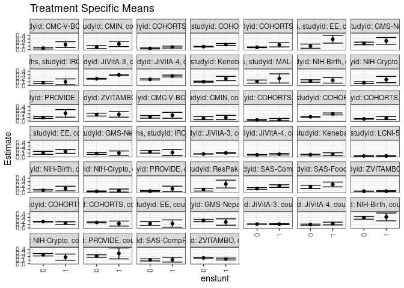

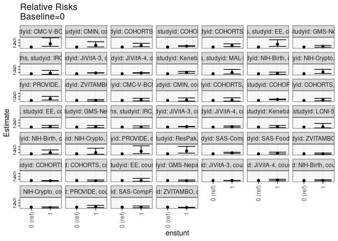

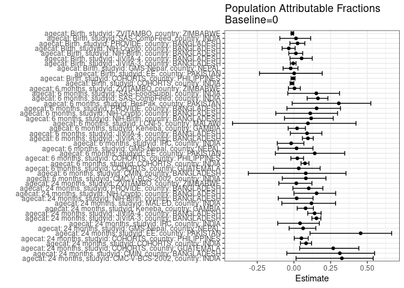

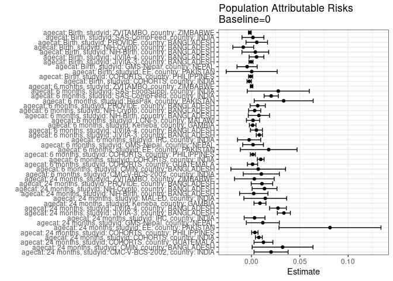

## Results Table

### Parameter: TSM

| agecat | studyid | country | intervention_level | baseline_level | estimate | ci_lower | ci_upper |
| --- | --- | --- | --- | --- | --- | --- | --- |
| Birth | COHORTS | INDIA | 0 | NA | 0.1793434 | 0.1694860 | 0.1892008 |
| Birth | COHORTS | INDIA | 1 | NA | 0.1385596 | 0.1026661 | 0.1744530 |
| Birth | COHORTS | PHILIPPINES | 0 | NA | 0.1564775 | 0.1430510 | 0.1699040 |
| Birth | COHORTS | PHILIPPINES | 1 | NA | 0.1244151 | 0.0537950 | 0.1950352 |
| Birth | EE | PAKISTAN | 0 | NA | 0.1240876 | 0.0687255 | 0.1794497 |
| Birth | EE | PAKISTAN | 1 | NA | 0.1250000 | 0.0222203 | 0.2277797 |
| Birth | GMS-Nepal | NEPAL | 0 | NA | 0.2104660 | 0.1769494 | 0.2439826 |
| Birth | GMS-Nepal | NEPAL | 1 | NA | 0.1679367 | 0.0773511 | 0.2585222 |
| Birth | JiVitA-3 | BANGLADESH | 0 | NA | 0.1100552 | 0.1044427 | 0.1156678 |
| Birth | JiVitA-3 | BANGLADESH | 1 | NA | 0.1083676 | 0.0966338 | 0.1201014 |
| Birth | JiVitA-4 | BANGLADESH | 0 | NA | 0.0945484 | 0.0780613 | 0.1110356 |
| Birth | JiVitA-4 | BANGLADESH | 1 | NA | 0.1246817 | 0.0857407 | 0.1636227 |
| Birth | NIH-Birth | BANGLADESH | 0 | NA | 0.2882129 | 0.2487144 | 0.3277114 |
| Birth | NIH-Birth | BANGLADESH | 1 | NA | 0.3119428 | 0.2013756 | 0.4225100 |
| Birth | NIH-Crypto | BANGLADESH | 0 | NA | 0.2517942 | 0.2177338 | 0.2858547 |
| Birth | NIH-Crypto | BANGLADESH | 1 | NA | 0.1842714 | 0.0977517 | 0.2707910 |
| Birth | PROVIDE | BANGLADESH | 0 | NA | 0.2144736 | 0.1781045 | 0.2508428 |
| Birth | PROVIDE | BANGLADESH | 1 | NA | 0.2881261 | 0.1336993 | 0.4425528 |
| Birth | SAS-CompFeed | INDIA | 0 | NA | 0.1054534 | 0.0755575 | 0.1353493 |
| Birth | SAS-CompFeed | INDIA | 1 | NA | 0.1119608 | 0.0454395 | 0.1784822 |
| Birth | ZVITAMBO | ZIMBABWE | 0 | NA | 0.1612653 | 0.1547413 | 0.1677892 |
| Birth | ZVITAMBO | ZIMBABWE | 1 | NA | 0.1303141 | 0.1038463 | 0.1567819 |
| 6 months | CMC-V-BCS-2002 | INDIA | 0 | NA | 0.1148251 | 0.0782243 | 0.1514259 |
| 6 months | CMC-V-BCS-2002 | INDIA | 1 | NA | 0.1601535 | 0.0766630 | 0.2436440 |
| 6 months | CMIN | BANGLADESH | 0 | NA | 0.0794702 | 0.0362411 | 0.1226993 |
| 6 months | CMIN | BANGLADESH | 1 | NA | 0.0978261 | 0.0369955 | 0.1586567 |
| 6 months | COHORTS | GUATEMALA | 0 | NA | 0.0321384 | 0.0199789 | 0.0442980 |
| 6 months | COHORTS | GUATEMALA | 1 | NA | 0.0389610 | 0.0083837 | 0.0695383 |
| 6 months | COHORTS | INDIA | 0 | NA | 0.1167290 | 0.1086338 | 0.1248241 |
| 6 months | COHORTS | INDIA | 1 | NA | 0.1988703 | 0.1712497 | 0.2264910 |

[output cut: 62 more lines]

### Parameter: E(Y)

| agecat | studyid | country | intervention_level | baseline_level | estimate | ci_lower | ci_upper |
| --- | --- | --- | --- | --- | --- | --- | --- |
| Birth | COHORTS | INDIA | NA | NA | 0.1769740 | 0.1674681 | 0.1864799 |
| Birth | COHORTS | PHILIPPINES | NA | NA | 0.1555709 | 0.1423748 | 0.1687670 |
| Birth | EE | PAKISTAN | NA | NA | 0.1242938 | 0.0755526 | 0.1730349 |
| Birth | GMS-Nepal | NEPAL | NA | NA | 0.2059282 | 0.1745993 | 0.2372572 |
| Birth | JiVitA-3 | BANGLADESH | NA | NA | 0.1095259 | 0.1044047 | 0.1146471 |
| Birth | JiVitA-4 | BANGLADESH | NA | NA | 0.0997496 | 0.0843744 | 0.1151247 |
| Birth | NIH-Birth | BANGLADESH | NA | NA | 0.2921739 | 0.2549711 | 0.3293768 |
| Birth | NIH-Crypto | BANGLADESH | NA | NA | 0.2432815 | 0.2116319 | 0.2749310 |
| Birth | PROVIDE | BANGLADESH | NA | NA | 0.2199248 | 0.1846953 | 0.2551543 |
| Birth | SAS-CompFeed | INDIA | NA | NA | 0.1069810 | 0.0760961 | 0.1378659 |
| Birth | ZVITAMBO | ZIMBABWE | NA | NA | 0.1595572 | 0.1532418 | 0.1658725 |
| 6 months | CMC-V-BCS-2002 | INDIA | NA | NA | 0.1250000 | 0.0911644 | 0.1588356 |
| 6 months | CMIN | BANGLADESH | NA | NA | 0.0864198 | 0.0510184 | 0.1218211 |
| 6 months | COHORTS | GUATEMALA | NA | NA | 0.0332295 | 0.0219033 | 0.0445557 |
| 6 months | COHORTS | INDIA | NA | NA | 0.1262774 | 0.1184108 | 0.1341439 |
| 6 months | COHORTS | PHILIPPINES | NA | NA | 0.0594974 | 0.0505830 | 0.0684118 |
| 6 months | EE | PAKISTAN | NA | NA | 0.1253333 | 0.0917776 | 0.1588891 |
| 6 months | GMS-Nepal | NEPAL | NA | NA | 0.0904255 | 0.0667359 | 0.1141152 |
| 6 months | IRC | INDIA | NA | NA | 0.1323529 | 0.0994307 | 0.1652752 |
| 6 months | JiVitA-3 | BANGLADESH | NA | NA | 0.0846640 | 0.0798626 | 0.0894653 |
| 6 months | JiVitA-4 | BANGLADESH | NA | NA | 0.0569005 | 0.0480577 | 0.0657432 |
| 6 months | Keneba | GAMBIA | NA | NA | 0.0579225 | 0.0479029 | 0.0679420 |
| 6 months | LCNI-5 | MALAWI | NA | NA | 0.0166865 | 0.0080138 | 0.0253592 |
| 6 months | NIH-Birth | BANGLADESH | NA | NA | 0.0651769 | 0.0442802 | 0.0860736 |
| 6 months | NIH-Crypto | BANGLADESH | NA | NA | 0.0293706 | 0.0169860 | 0.0417552 |
| 6 months | PROVIDE | BANGLADESH | NA | NA | 0.0414594 | 0.0255348 | 0.0573839 |
| 6 months | ResPak | PAKISTAN | NA | NA | 0.1087866 | 0.0692283 | 0.1483450 |
| 6 months | SAS-CompFeed | INDIA | NA | NA | 0.1244378 | 0.0992652 | 0.1496104 |
| 6 months | SAS-FoodSuppl | INDIA | NA | NA | 0.1815789 | 0.1427684 | 0.2203895 |
| 6 months | ZVITAMBO | ZIMBABWE | NA | NA | 0.0311581 | 0.0274654 | 0.0348509 |
| 24 months | CMC-V-BCS-2002 | INDIA | NA | NA | 0.0618280 | 0.0373207 | 0.0863352 |
| 24 months | CMIN | BANGLADESH | NA | NA | 0.1028807 | 0.0646041 | 0.1411572 |
| 24 months | COHORTS | GUATEMALA | NA | NA | 0.0462107 | 0.0336957 | 0.0587258 |
| 24 months | COHORTS | INDIA | NA | NA | 0.0916651 | 0.0838893 | 0.0994409 |
| 24 months | COHORTS | PHILIPPINES | NA | NA | 0.0681911 | 0.0582056 | 0.0781766 |
| 24 months | EE | PAKISTAN | NA | NA | 0.1785714 | 0.1204842 | 0.2366587 |
| 24 months | GMS-Nepal | NEPAL | NA | NA | 0.1868583 | 0.1522030 | 0.2215136 |
| 24 months | IRC | INDIA | NA | NA | 0.0757946 | 0.0501131 | 0.1014762 |
| 24 months | JiVitA-3 | BANGLADESH | NA | NA | 0.2182959 | 0.2084450 | 0.2281469 |
| 24 months | JiVitA-4 | BANGLADESH | NA | NA | 0.1942978 | 0.1810880 | 0.2075076 |
| 24 months | Keneba | GAMBIA | NA | NA | 0.1106605 | 0.0958563 | 0.1254646 |
| 24 months | MAL-ED | INDIA | NA | NA | 0.1189427 | 0.0767376 | 0.1611478 |
| 24 months | NIH-Birth | BANGLADESH | NA | NA | 0.1238318 | 0.0925894 | 0.1550741 |
| 24 months | NIH-Crypto | BANGLADESH | NA | NA | 0.0875486 | 0.0630907 | 0.1120065 |
| 24 months | PROVIDE | BANGLADESH | NA | NA | 0.1070812 | 0.0818727 | 0.1322897 |
| 24 months | ZVITAMBO | ZIMBABWE | NA | NA | 0.1824480 | 0.1460286 | 0.2188675 |

### Parameter: RR

| agecat | studyid | country | intervention_level | baseline_level | estimate | ci_lower | ci_upper |
| --- | --- | --- | --- | --- | --- | --- | --- |
| Birth | COHORTS | INDIA | 0 | 0 | 1.0000000 | 1.0000000 | 1.0000000 |
| Birth | COHORTS | INDIA | 1 | 0 | 0.7725936 | 0.5928863 | 1.0067713 |
| Birth | COHORTS | PHILIPPINES | 0 | 0 | 1.0000000 | 1.0000000 | 1.0000000 |
| Birth | COHORTS | PHILIPPINES | 1 | 0 | 0.7950991 | 0.4478950 | 1.4114528 |
| Birth | EE | PAKISTAN | 0 | 0 | 1.0000000 | 1.0000000 | 1.0000000 |
| Birth | EE | PAKISTAN | 1 | 0 | 1.0073529 | 0.3952817 | 2.5671818 |
| Birth | GMS-Nepal | NEPAL | 0 | 0 | 1.0000000 | 1.0000000 | 1.0000000 |
| Birth | GMS-Nepal | NEPAL | 1 | 0 | 0.7979278 | 0.4546176 | 1.4004930 |
| Birth | JiVitA-3 | BANGLADESH | 0 | 0 | 1.0000000 | 1.0000000 | 1.0000000 |
| Birth | JiVitA-3 | BANGLADESH | 1 | 0 | 0.9846660 | 0.8755285 | 1.1074078 |
| Birth | JiVitA-4 | BANGLADESH | 0 | 0 | 1.0000000 | 1.0000000 | 1.0000000 |
| Birth | JiVitA-4 | BANGLADESH | 1 | 0 | 1.3187072 | 0.9253364 | 1.8793044 |
| Birth | NIH-Birth | BANGLADESH | 0 | 0 | 1.0000000 | 1.0000000 | 1.0000000 |
| Birth | NIH-Birth | BANGLADESH | 1 | 0 | 1.0823347 | 0.7409554 | 1.5809970 |
| Birth | NIH-Crypto | BANGLADESH | 0 | 0 | 1.0000000 | 1.0000000 | 1.0000000 |
| Birth | NIH-Crypto | BANGLADESH | 1 | 0 | 0.7318331 | 0.4485470 | 1.1940325 |
| Birth | PROVIDE | BANGLADESH | 0 | 0 | 1.0000000 | 1.0000000 | 1.0000000 |
| Birth | PROVIDE | BANGLADESH | 1 | 0 | 1.3434101 | 0.7664361 | 2.3547308 |
| Birth | SAS-CompFeed | INDIA | 0 | 0 | 1.0000000 | 1.0000000 | 1.0000000 |
| Birth | SAS-CompFeed | INDIA | 1 | 0 | 1.0617093 | 0.6082852 | 1.8531220 |
| Birth | ZVITAMBO | ZIMBABWE | 0 | 0 | 1.0000000 | 1.0000000 | 1.0000000 |
| Birth | ZVITAMBO | ZIMBABWE | 1 | 0 | 0.8080730 | 0.6569587 | 0.9939469 |
| 6 months | CMC-V-BCS-2002 | INDIA | 0 | 0 | 1.0000000 | 1.0000000 | 1.0000000 |
| 6 months | CMC-V-BCS-2002 | INDIA | 1 | 0 | 1.3947603 | 0.7564073 | 2.5718369 |
| 6 months | CMIN | BANGLADESH | 0 | 0 | 1.0000000 | 1.0000000 | 1.0000000 |
| 6 months | CMIN | BANGLADESH | 1 | 0 | 1.2309783 | 0.5388246 | 2.8122463 |
| 6 months | COHORTS | GUATEMALA | 0 | 0 | 1.0000000 | 1.0000000 | 1.0000000 |
| 6 months | COHORTS | GUATEMALA | 1 | 0 | 1.2122877 | 0.5072524 | 2.8972591 |
| 6 months | COHORTS | INDIA | 0 | 0 | 1.0000000 | 1.0000000 | 1.0000000 |
| 6 months | COHORTS | INDIA | 1 | 0 | 1.7036934 | 1.4588081 | 1.9896868 |

[output cut: 62 more lines]

### Parameter: PAR

| agecat | studyid | country | intervention_level | baseline_level | estimate | ci_lower | ci_upper |
| --- | --- | --- | --- | --- | --- | --- | --- |
| Birth | COHORTS | INDIA | 0 | NA | -0.0023694 | -0.0046302 | -0.0001085 |
| Birth | COHORTS | PHILIPPINES | 0 | NA | -0.0009066 | -0.0030258 | 0.0012126 |
| Birth | EE | PAKISTAN | 0 | NA | 0.0002062 | -0.0261762 | 0.0265886 |
| Birth | GMS-Nepal | NEPAL | 0 | NA | -0.0045378 | -0.0149837 | 0.0059082 |
| Birth | JiVitA-3 | BANGLADESH | 0 | NA | -0.0005293 | -0.0026366 | 0.0015780 |
| Birth | JiVitA-4 | BANGLADESH | 0 | NA | 0.0052011 | -0.0023894 | 0.0127917 |
| Birth | NIH-Birth | BANGLADESH | 0 | NA | 0.0039610 | -0.0098765 | 0.0177985 |
| Birth | NIH-Crypto | BANGLADESH | 0 | NA | -0.0085128 | -0.0193062 | 0.0022807 |
| Birth | PROVIDE | BANGLADESH | 0 | NA | 0.0054512 | -0.0057121 | 0.0166145 |
| Birth | SAS-CompFeed | INDIA | 0 | NA | 0.0015276 | -0.0097918 | 0.0128469 |
| Birth | ZVITAMBO | ZIMBABWE | 0 | NA | -0.0017081 | -0.0030772 | -0.0003389 |
| 6 months | CMC-V-BCS-2002 | INDIA | 0 | NA | 0.0101749 | -0.0084914 | 0.0288412 |
| 6 months | CMIN | BANGLADESH | 0 | NA | 0.0069496 | -0.0213264 | 0.0352255 |
| 6 months | COHORTS | GUATEMALA | 0 | NA | 0.0010910 | -0.0041736 | 0.0063557 |
| 6 months | COHORTS | INDIA | 0 | NA | 0.0095484 | 0.0060783 | 0.0130186 |
| 6 months | COHORTS | PHILIPPINES | 0 | NA | 0.0013818 | -0.0011929 | 0.0039565 |
| 6 months | EE | PAKISTAN | 0 | NA | 0.0177903 | -0.0115503 | 0.0471308 |
| 6 months | GMS-Nepal | NEPAL | 0 | NA | 0.0016306 | -0.0091092 | 0.0123704 |
| 6 months | IRC | INDIA | 0 | NA | -0.0024785 | -0.0144652 | 0.0095081 |
| 6 months | JiVitA-3 | BANGLADESH | 0 | NA | 0.0080897 | 0.0049173 | 0.0112620 |
| 6 months | JiVitA-4 | BANGLADESH | 0 | NA | 0.0050844 | -0.0011199 | 0.0112888 |
| 6 months | Keneba | GAMBIA | 0 | NA | 0.0012353 | -0.0021739 | 0.0046445 |
| 6 months | LCNI-5 | MALAWI | 0 | NA | 0.0015922 | -0.0052488 | 0.0084332 |
| 6 months | NIH-Birth | BANGLADESH | 0 | NA | 0.0076548 | -0.0033541 | 0.0186637 |
| 6 months | NIH-Crypto | BANGLADESH | 0 | NA | 0.0032695 | -0.0030052 | 0.0095442 |
| 6 months | PROVIDE | BANGLADESH | 0 | NA | 0.0064040 | -0.0014720 | 0.0142800 |
| 6 months | ResPak | PAKISTAN | 0 | NA | 0.0332877 | 0.0027813 | 0.0637942 |
| 6 months | SAS-CompFeed | INDIA | 0 | NA | 0.0203868 | 0.0130424 | 0.0277313 |
| 6 months | SAS-FoodSuppl | INDIA | 0 | NA | 0.0276874 | -0.0044006 | 0.0597754 |
| 6 months | ZVITAMBO | ZIMBABWE | 0 | NA | 0.0001153 | -0.0011521 | 0.0013826 |
| 24 months | CMC-V-BCS-2002 | INDIA | 0 | NA | 0.0202141 | 0.0025926 | 0.0378355 |
| 24 months | CMIN | BANGLADESH | 0 | NA | 0.0321885 | 0.0007292 | 0.0636479 |
| 24 months | COHORTS | GUATEMALA | 0 | NA | 0.0123798 | 0.0026232 | 0.0221364 |
| 24 months | COHORTS | INDIA | 0 | NA | 0.0075907 | 0.0040417 | 0.0111397 |
| 24 months | COHORTS | PHILIPPINES | 0 | NA | 0.0034821 | 0.0002127 | 0.0067514 |
| 24 months | EE | PAKISTAN | 0 | NA | 0.0812002 | 0.0284702 | 0.1339302 |
| 24 months | GMS-Nepal | NEPAL | 0 | NA | 0.0117128 | -0.0053552 | 0.0287807 |
| 24 months | IRC | INDIA | 0 | NA | 0.0031689 | -0.0075896 | 0.0139274 |
| 24 months | JiVitA-3 | BANGLADESH | 0 | NA | 0.0334818 | 0.0267577 | 0.0402059 |
| 24 months | JiVitA-4 | BANGLADESH | 0 | NA | 0.0273615 | 0.0186494 | 0.0360737 |
| 24 months | Keneba | GAMBIA | 0 | NA | 0.0087791 | 0.0025895 | 0.0149688 |
| 24 months | MAL-ED | INDIA | 0 | NA | 0.0142307 | -0.0078630 | 0.0363244 |
| 24 months | NIH-Birth | BANGLADESH | 0 | NA | 0.0023284 | -0.0123366 | 0.0169935 |
| 24 months | NIH-Crypto | BANGLADESH | 0 | NA | 0.0135094 | 0.0006557 | 0.0263631 |
| 24 months | PROVIDE | BANGLADESH | 0 | NA | 0.0108076 | -0.0003283 | 0.0219434 |
| 24 months | ZVITAMBO | ZIMBABWE | 0 | NA | 0.0029512 | -0.0175802 | 0.0234826 |

### Parameter: PAF

| agecat | studyid | country | intervention_level | baseline_level | estimate | ci_lower | ci_upper |
| --- | --- | --- | --- | --- | --- | --- | --- |
| Birth | COHORTS | INDIA | 0 | NA | -0.0133883 | -0.0262359 | -0.0007015 |
| Birth | COHORTS | PHILIPPINES | 0 | NA | -0.0058277 | -0.0195368 | 0.0076971 |
| Birth | EE | PAKISTAN | 0 | NA | 0.0016589 | -0.2348505 | 0.1928700 |
| Birth | GMS-Nepal | NEPAL | 0 | NA | -0.0220356 | -0.0739820 | 0.0273983 |
| Birth | JiVitA-3 | BANGLADESH | 0 | NA | -0.0048326 | -0.0242506 | 0.0142172 |
| Birth | JiVitA-4 | BANGLADESH | 0 | NA | 0.0521421 | -0.0267232 | 0.1249494 |
| Birth | NIH-Birth | BANGLADESH | 0 | NA | 0.0135571 | -0.0349647 | 0.0598040 |
| Birth | NIH-Crypto | BANGLADESH | 0 | NA | -0.0349914 | -0.0802742 | 0.0083933 |
| Birth | PROVIDE | BANGLADESH | 0 | NA | 0.0247865 | -0.0272520 | 0.0741889 |
| Birth | SAS-CompFeed | INDIA | 0 | NA | 0.0142789 | -0.0962645 | 0.1136755 |
| Birth | ZVITAMBO | ZIMBABWE | 0 | NA | -0.0107051 | -0.0193133 | -0.0021696 |
| 6 months | CMC-V-BCS-2002 | INDIA | 0 | NA | 0.0813991 | -0.0795095 | 0.2183231 |
| 6 months | CMIN | BANGLADESH | 0 | NA | 0.0804163 | -0.3105913 | 0.3547689 |
| 6 months | COHORTS | GUATEMALA | 0 | NA | 0.0328337 | -0.1388794 | 0.1786571 |
| 6 months | COHORTS | INDIA | 0 | NA | 0.0756147 | 0.0480537 | 0.1023777 |
| 6 months | COHORTS | PHILIPPINES | 0 | NA | 0.0232240 | -0.0208918 | 0.0654334 |
| 6 months | EE | PAKISTAN | 0 | NA | 0.1419436 | -0.1264312 | 0.3463775 |
| 6 months | GMS-Nepal | NEPAL | 0 | NA | 0.0180326 | -0.1081330 | 0.1298337 |
| 6 months | IRC | INDIA | 0 | NA | -0.0187266 | -0.1133497 | 0.0678546 |
| 6 months | JiVitA-3 | BANGLADESH | 0 | NA | 0.0955503 | 0.0577024 | 0.1318780 |
| 6 months | JiVitA-4 | BANGLADESH | 0 | NA | 0.0893569 | -0.0244903 | 0.1905528 |
| 6 months | Keneba | GAMBIA | 0 | NA | 0.0213262 | -0.0392642 | 0.0783840 |
| 6 months | LCNI-5 | MALAWI | 0 | NA | 0.0954178 | -0.4186525 | 0.4232069 |
| 6 months | NIH-Birth | BANGLADESH | 0 | NA | 0.1174463 | -0.0642104 | 0.2680948 |
| 6 months | NIH-Crypto | BANGLADESH | 0 | NA | 0.1113183 | -0.1239256 | 0.2973243 |
| 6 months | PROVIDE | BANGLADESH | 0 | NA | 0.1544649 | -0.0475894 | 0.3175480 |
| 6 months | ResPak | PAKISTAN | 0 | NA | 0.3059909 | -0.0120683 | 0.5240948 |
| 6 months | SAS-CompFeed | INDIA | 0 | NA | 0.1638316 | 0.0901554 | 0.2315417 |
| 6 months | SAS-FoodSuppl | INDIA | 0 | NA | 0.1524813 | -0.0420922 | 0.3107251 |
| 6 months | ZVITAMBO | ZIMBABWE | 0 | NA | 0.0036995 | -0.0378166 | 0.0435549 |
| 24 months | CMC-V-BCS-2002 | INDIA | 0 | NA | 0.3269403 | 0.0144303 | 0.5403579 |
| 24 months | CMIN | BANGLADESH | 0 | NA | 0.3128726 | -0.0485084 | 0.5496993 |
| 24 months | COHORTS | GUATEMALA | 0 | NA | 0.2678990 | 0.0390051 | 0.4422740 |
| 24 months | COHORTS | INDIA | 0 | NA | 0.0828093 | 0.0439378 | 0.1201004 |
| 24 months | COHORTS | PHILIPPINES | 0 | NA | 0.0510633 | 0.0024384 | 0.0973182 |
| 24 months | EE | PAKISTAN | 0 | NA | 0.4547212 | 0.1095849 | 0.6660782 |
| 24 months | GMS-Nepal | NEPAL | 0 | NA | 0.0626825 | -0.0328518 | 0.1493804 |
| 24 months | IRC | INDIA | 0 | NA | 0.0418093 | -0.1104940 | 0.1732244 |
| 24 months | JiVitA-3 | BANGLADESH | 0 | NA | 0.1533781 | 0.1221920 | 0.1834563 |
| 24 months | JiVitA-4 | BANGLADESH | 0 | NA | 0.1408226 | 0.0940110 | 0.1852156 |
| 24 months | Keneba | GAMBIA | 0 | NA | 0.0793338 | 0.0225108 | 0.1328536 |
| 24 months | MAL-ED | INDIA | 0 | NA | 0.1196432 | -0.0825540 | 0.2840744 |
| 24 months | NIH-Birth | BANGLADESH | 0 | NA | 0.0188032 | -0.1069868 | 0.1302993 |
| 24 months | NIH-Crypto | BANGLADESH | 0 | NA | 0.1543074 | 0.0001366 | 0.2847064 |
| 24 months | PROVIDE | BANGLADESH | 0 | NA | 0.1009288 | -0.0069804 | 0.1972743 |
| 24 months | ZVITAMBO | ZIMBABWE | 0 | NA | 0.0161756 | -0.1029961 | 0.1224715 |